# Managing the “Downside” of Downsizing: Firms' Impression Offsetting around Downsizing Announcements

Converted from PDF `Brauer-DownsizingImpressionOffsetting-2023-JMS.pdf` · 33 pages · anchors: page `#pN`, block `#pN-bK`

### **Managing the “Downside” of Downsizing: Firms’ Impression Offsetting around Downsizing Announcements**

### **Matthias Brauer and Louis Vandepoele**

*University of Mannheim*

ABSTRACT Past studies indicate that investors perceive workforce downsizing negatively, as evidenced by negative short-term stock returns around downsizing announcements. Impression management theory suggests that downsizing firms thus attempt to offset investors’ negative impressions by issuing positive news around downsizing announcements, and that firms’ impression offsetting can attenuate investors’ negative response. In this study, we test these theoretical predictions but also unpack *why* and *how* impression offsetting positively biases investor perceptions. Prior work theorized that impression offsetting is effective because it dilutes investors’ attention and compels them to average positive and negative news items in their minds but did not clarify whether both causal mechanisms are operative, and which one is more powerful. We posit that impression offsetting influences investor response primarily by forcing them to mentally average positive and negative news. Further, our study provides a more nuanced understanding of investors’ mental averaging process. While prior work assumed that all types of positive news are received equally by investors, we argue that positive financial news offsets investors’ negative impressions more effectively than positive operational or social news. The empirical analysis of nearly 1500 downsizing announcements by the largest, public US firms between 2001 and 2020 mainly supports our theoretical reasoning.

**Keywords:** impression offsetting, investor response, organizational impression management, workforce downsizing

#### **INTRODUCTION**

Workforce downsizing, conceptualized as an ‘intentional reduction in the number of people of an organization’ (Brauer and Laamanen, 2014, p. 1313), is a highly prevalent managerial practice. Even the world’s most successful and highly valued firms like Alphabet,

*Journal of Management Studies* 0:0 #### 2023 doi:10.1111/joms.13024

*Address for reprints:* Matthias Brauer, Chair of Strategic and International Management, University of Mannheim, Schloss, 68131 Mannheim, Germany (matthias.brauer@uni-mannheim.de).

Meta, or Microsoft recently announced sizeable workforce reductions to cope with the ‘tech crunch’ and a looming recession (Bushard, 2023). Research has shown that downsizing evokes negative perceptions and responses not only by employees but also by investors (see Datta and Basuil, 2015; Datta et al., 2010, 2012 for reviews). As firms aim to preserve favourable perceptions of key stakeholders to maintain their vital support (Elsbach et al., 1998; Westphal and Graebner, 2010), impression management (IM) theory suggests that firms are motivated to engage in IM activities to attenuate negative impressions of investors caused by workforce downsizing (see Bolino et al., 2008, 2016 for reviews).

Prior studies on organizational IM for financial markets have generated valuable insights into how firms strategically disclose information to influence investor or analyst impressions (e.g., Hayward and Fitza, 2017; Lamin and Zaheer, 2012; Washburn and Bromiley, 2014; Westphal and Graebner, 2010). Washburn and Bromiley (2014), for instance, show that the extent firms’ earnings diverge from analyst forecasts makes firms less likely to issue forecast guidance, but makes them issue more press releases and host more conference calls to influence subsequent analyst forecasts. Additionally, Hayward and Fitza (2017) find that firms strategically issue more precise earnings forecasts to restore favourable investor impressions after material organizational setbacks.

To complement this important line of work on reactive IM, we focus on firms’ anticipatory IM to attenuate investors’ negative response to workforce downsizing. While reactive IM occurs in response to a negative event, anticipatory IM is used by firms in anticipation – i.e., before or concurrent with – events that may lead to negative audience reactions (Elsbach et al., 1998; Graffin et al., 2016). To alleviate a negative audience reaction, anticipatory IM research suggests that firms make use of impression offsetting, defined as ‘organizational actions initiated to positively influence external perceptions of the organization by releasing positive, but unrelated, information, in anticipation of [a negative] event becoming known’ (Graffin et al., 2016, p. 233). While prior anticipatory IM research has mostly focused on the *antecedents* of impression offsetting (Gamache et al., 2019; see Graffin et al., 2016 for the only exception), our study complements extant studies on anticipatory IM by exploring the *effectiveness* of impression offsetting.

To substantively advance extant theorizing on the effectiveness of impression offsetting, we not only examine the use and effectiveness of impression offsetting in the context of workforce downsizing, but also unpack *why* and *how* impression offsetting attenuates investors’ negative response. Prior theorizing on impression offsetting has argued that its effectiveness can be explained by two causal mechanisms: first, attention dilution, i.e., the fact that impression offsetting ‘direct[s] shareholder attention away from the [negative news]’ (Gamache et al., 2019, p. 1313), and second, mental averaging, i.e., the fact that impression offsetting ‘forces investors to assess and likely “average” multiple pieces of information simultaneously’ (Graffin et al., 2016, p. 237). Yet, it has remained unexamined whether both causal mechanisms are actually operative, and which of the two causal mechanisms is more powerful. Addressing this question is theoretically relevant, as it resolves the conceptual ambiguity around how impression offsetting works and augments our understanding of why impression offsetting is an effective influence tactic towards investors. Building on IM theory (Goffman, 1959; Schlenker, 1980) and research in cognitive psychology (Fiske and

Taylor, 2017; Kahneman, 1973), we posit that mental averaging is the more powerful causal mechanism that explains why impression offsetting effectively attenuates investors’ negative response to downsizing. This is because, first, investors are an audience that is highly accustomed to processing large amounts of complex information in short periods of time and, second, positive news has particularly high marginal utility in negative information environments.

Our study also differs from prior works on impression offsetting by theorizing that, besides the sheer *amount* of positive information, the *type* of positive information that is used to offset negative impressions plays a crucial role for impression offsetting’s effectiveness. We distinguish between the release of positive financial, operational, and social news, as downsizing gives rise to financial, operational, and social concerns among investors. Such a distinction between different types of positive news appears theoretically meaningful, as individuals have been found to attribute greater weight to information which fits the idiosyncratic, socially situated schemas that guide their cognitive processes (Fiske and Taylor, 2017; König et al., 2018; Lamin and Zaheer, 2012). In our specific context, this suggests that positive financial news is more effective in offsetting investors’ negative perceptions compared to positive operational and social news.

Based on a sample of 1449 workforce downsizings by the largest 250 US firms between 2001 and 2020, we find that firms make use of impression offsetting by releasing an abnormally large number of positive news items around downsizing announcements. Consistent with our predictions, results further indicate that impression offsetting significantly attenuates negative investor response to downsizing announcements, and that mental averaging is the more powerful mechanism causing this attenuating effect. Importantly, our empirical findings also suggest that the effectiveness of impression offsetting differs by the type of positive news released.

Our study makes several contributions. First, we contribute to IM literature by advancing research on firms’ IM for financial markets, i.e., investors or analysts (e.g., Hayward and Fitza, 2017; Pan et al., 2018; Washburn and Bromiley, 2014; Westphal and Clement, 2008; Westphal and Graebner, 2010; Whittington et al., 2016). More specifically, we add to the emerging research stream on how firms can ‘pre-emptively’ – rather than reactively – attenuate investors’ negative response using anticipatory IM (Busenbark et al., 2017; Graffin et al., 2016). While Graffin et al. (2016) were first to show that impression offsetting constitutes an effective influence tactic in the context of acquisitions, our study indicates that the effectiveness of impression offsetting extends to workforce reductions. This is theoretically non-obvious, as workforce reductions are perceived significantly more negatively by investors than acquisitions (Datta and Basuil, 2015; Datta et al., 2010, 2012; Moeller et al., 2005). Moreover, as noted by Bettis et al. (2016), such quasi-replications have scientific utility, as they are critical for building a cumulative body of research knowledge – especially so if our theoretical knowledge is grounded on a single study or less than a handful of studies, as is the case for research on impression offsetting.

Second, we contribute to emerging research on the effectiveness of anticipatory IM tactics and extend theory on impression offsetting by unpacking *why* and *how* it works with respect to investors. Prior impression offsetting studies (Gamache et al., 2019; Graffin et al., 2016) have proposed two mechanisms by which it positively biases investor perceptions but have yet to explore whether both are actually operative, and which one is more

powerful. We take a first step to resolve this conceptual ambiguity by providing strong empirical evidence for the mental averaging mechanism and weaker evidence for the attention dilution mechanism. Collectively, our theorizing and empirical results suggest that impression offsetting works primarily by forcing investors to mentally average positive and negative news.

In addition, our study provides a more nuanced understanding of investors’ mental averaging. While prior impression offsetting studies have assumed that all types of positive news items are received equally by investors (Gamache et al., 2019; Graffin et al., 2016), we reason and find that the marginal utility of positive information differs by type and that the effectiveness of impression offsetting depends on the extent to which the type of positive information conforms to investors’ cognitive schemas and preferences. Thereby, our study hints at the importance of audience-specific characteristics (i.e., its preferences and cognitive information processing) for the effectiveness of IM, an aspect that received little attention in IM literature (Bolino et al., 2008).

Third, we contribute to workforce downsizing literature. While investors’ negative response to workforce downsizing is well documented, we innovate by highlighting how firms can effectively attenuate investors’ negative response using anticipatory IM. We thus respond to prior calls to explore how contextual factors, such as the downsizing firm’s communication, influence investor response to downsizing (Datta et al., 2010, 2012) and to calls to investigate whether and how firms can neutralize the negative effects of their downsizing decisions (Brauer and Zimmermann, 2019). The only study so far on this subject by Nègre et al. (2017) focused on the influence tactic of justification and found that justifications do not attenuate but amplify negative investor response. In contrast, we show that anticipatory IM in the form of positive press releases that do not seek to explain the downsizing but rather aim to positively bias investors’ perception constitutes a more effective influence tactic to reduce negative investor response.

#### **BACKGROUND AND HYPOTHESES**

#### **Investor Response to Workforce Downsizing Announcements**

A review of both early and recent downsizing studies shows that 34 out of 37 studies on investor response to workforce downsizing find negative abnormal returns around the day of a downsizing announcement (e.g., Brauer and Zimmermann, 2019; Chen et al., 2001; Hillier et al., 2007; Lee, 1997; Nixon et al., 2004; Schulz and Himme, 2022; Worrell et al., 1991). Negative investor response has been found to be particularly pronounced when downsizings are larger (Lee, 1997; Nixon et al., 2004; Worrell et al., 1991), are undertaken in response to declining demand or poor performance (Elayan et al., 1998; Palmon et al., 1997), and occur in industry downsizing waves (Brauer and Zimmermann, 2019) or in a negative market environment (Marshall et al., 2012). In addition, workforce downsizing has been found to negatively affect a firm’s reputation (Flanagan and O’Shaughnessy, 2005; Love and Kraatz, 2009; Zyglidopoulos, 2005). Studies show that when firms downsize workers, they lose up to two-thirds of their position in intra-industry reputation rankings on average (Flanagan and O’Shaughnessy, 2005; Love and Kraatz, 2009).

Prior research has put forward multiple reasons for the negative perception of and response to workforce downsizing by investors. First, workforce downsizing is usually accompanied by substantial direct and indirect costs. Direct costs include severance payments for laid-off employees, expenses for outplacement services, and restructuring costs (Brauer and Zimmermann, 2019; Cascio, 1993; Cascio et al., 2021). Indirect costs arise from knowledge losses and the disruption of organizational routines (Brauer and Laamanen, 2014; Nixon et al., 2004; Shah, 2000) as well as negative psychological effects on those employees ‘surviving’ the downsizing (Amabile and Conti, 1999; Brockner et al., 2004; Trevor and Nyberg, 2008).

Second, investors have been argued to interpret workforce downsizing announcements as an indication of severe financial trouble and unfavourable environmental conditions, such as lower future demand (Cagle et al., 2009; Farber and Hallock, 2009), stronger industry competition (Lee, 1997), or declining investment and growth opportunities (Lin and Rozeff, 1993). Hence, investors often perceive workforce downsizing as a signal of organizational decline rather than a deliberate strategic decision to reorganize for future growth (McKinley et al., 2000; Worrell et al., 1991).

Lastly, research has argued and shown that investors and other vital stakeholders often perceive workforce downsizing as a sign of a dismal organizational character (Love and Kraatz, 2009). Workforce downsizing inflicts severe psychological and physical harm on the employees affected, their relatives, and the communities a downsizing firm operates in (Cascio, 1993; Dlouhy and Casper, 2021; Shepherd and Williams, 2018). Downsizing is thus frequently perceived as a breach of an implicit ‘psychological contract’ with employees (Brockner et al., 2004; Robinson et al., 1994; Spreitzer and Mishra, 2002). Hence, investors are likely to perceive the downsizing firm as behaving opportunistically and as ‘an untrustworthy actor that might not be counted on to meet its commitments in the future’ (Love and Kraatz, 2009, p. 319). Consequently, workforce downsizing could provoke not only investors but also other vital stakeholders, such as banks, customers, or employees, to withdraw from the firm, leaving it with insufficient resources (e.g., Homburg et al., 2012; Trevor and Nyberg, 2008).

The preceding review of past downsizing literature strongly suggests that firms anticipate a negative response of investors to downsizing. As firms strive for favourable investor and analyst perceptions (e.g., Hayward and Fitza, 2017; Westphal and Clement, 2008; Westphal and Graebner, 2010), firms are motivated to engage in ‘pre-emptive’ IM to reduce investors’ negative response. This motivation is presumably particularly strong in the context of downsizing. As outlined above, investors often interpret downsizing as an indication of severe financial trouble and unfavourable environmental conditions. By releasing positive financial (e.g., dividend increases) and positive operational news items (e.g., customer wins), firms attempt to reduce doubts about the economic viability of their operations and pre-empt significant declines in investor confidence. As investors may view downsizing as a sign of dismal organizational character, firms are also motivated to release positive social news items (e.g., donations). Thereby, a downsizing firm intends to prevent investors from forming negative impressions about its moral character and trustworthiness, which could lead investors to withdraw from the firm. Given these various economic and reputational risks, anticipatory IM theory suggests that downsizing firms are motivated to release an abnormally large number of positive news items (e.g.,

dividend increases, customer wins, or new product releases) shortly before or contemporaneously to a downsizing announcement to offset investors’ negative perceptions. Hence, we propose:

*Hypothesis 1:* Downsizing firms release a greater number of positive news items around workforce downsizing announcements than is predicted by the baseline count of positive news item releases.

#### **The Influence of Impression Offsetting on Investor Response to Workforce Downsizing Announcements**

IM theory suggests that the extent of impression offsetting (i.e., the number of positive news items) around a downsizing announcement is likely to attenuate investors’ negative perception via two underlying mechanisms – attention dilution and mental averaging (Elsbach et al., 1998; Gamache et al., 2019; Graffin et al., 2011, 2016). Attention dilution means that the release of positive news splits investors’ attention over multiple pieces of information and draws their attention away from the negative event (Gamache et al., 2019, p. 1313). Mental averaging suggests that investors are forced to ‘average’ the positive news items and the negative downsizing information in their minds (Graffin et al., 2016, p. 237). The more positive news items are released, the less weight is given to the negative downsizing. Based on these two causal mechanisms, we predict that impression offsetting positively influences investor response to downsizing and that this effect is stronger, the greater the number of positive news items released by a downsizing firm:

*Hypothesis 2:* Impression offsetting is associated with a less negative investor response to workforce downsizing announcements.

While prior work reasons that attention dilution and mental averaging explain the effectiveness of impression offsetting towards investors (Gamache et al., 2019; Graffin et al., 2016), we fail to understand which of these two causal mechanisms is more powerful. Anticipatory IM theory suggests that an IM tactic which exclusively affects an audience through attention dilution is strategic noise (Elsbach et al., 1998; Graffin et al., 2011; Jin et al., 2022). Strategic noise ‘refers to any news [i.e., positive, negative, or neutral] releases controlled and sent by a firm around the time of a decision announcement’ (Jin et al., 2022, p. 1303) to ‘minimize direct scrutiny of the event’ (Graffin et al., 2011, p. 749). If attention dilution were the more powerful causal mechanism explaining impression offsetting’s effectiveness, the effect of impression offsetting on investor response would not meaningfully differ from that of strategic noise. By contrast, if mental averaging were the more powerful causal mechanism, the effect of impression offsetting on investor response would be substantially greater than that of strategic noise.

Research in cognitive psychology suggests that attention dilution occurs if individuals’ cognitive effort and arousal are high (Fiske and Taylor, 2017; Kahneman, 1973). Specifically, when confronted with complex tasks, such as the processing of multiple press releases in a short period of time, individuals are less able to discriminate between

which informational cues are relevant and which are not (Fiske and Taylor, 2017; Kahneman, 1973). Yet, attention literature has argued and shown that individuals’ information processing capacity differs greatly (Ocasio, 1997, 2011). Investors are constantly searching for new information on their investments to evaluate their value (Lamin and Zaheer, 2012). Investors are thus highly experienced in processing large amounts of news and distinguishing relevant from non-relevant news. Additionally, investors’ information processing capabilities are enhanced by information intermediaries, most notably security analysts. Security analysts serve as knowledgeable and trusted experts on firms for investors and regularly issue detailed forecasts and reports to help investors assess important news on their investments (Brauer and Wiersema, 2018; König et al., 2018). Consequently, firms’ chances to overburden investors’ information processing abilities and to significantly dilute their attention by releasing large numbers of news items of any kind (i.e., strategic noise) seem limited.

In contrast, the marginal utility of making investors mentally average negative and positive news seems particularly high in the context of downsizing announcements. In negative information environments, investors have been found to be prone to pessimism bias and to form particularly negative beliefs about a firm’s prospects (Baker and Wurgler, 2007; Bergman and Roychowdhury, 2008; Kuhnen, 2015). Forcing investors to evaluate a negative downsizing announcement concurrently with exclusively positive news appears most effective to counterbalance investors’ overly pessimistic beliefs caused by workforce downsizing. It also avoids that a downward spiral is put in motion. By provoking a more balanced reading of the firm’s prospects, the release of exclusively positive news prevents investors from categorizing a downsizing firm as a ‘crisis case’. Taken together, we thus propose that mental averaging – rather than attention dilution – is the more powerful causal mechanism explaining impression offsetting’s effectiveness towards investors. As a result, we expect impression offsetting to have a greater attenuating effect than strategic noise in the context of workforce downsizing. From this follows:

*Hypothesis 3:* Impression offsetting is more effective in attenuating negative investor response to workforce downsizing announcements than strategic noise, merely aimed at diluting investor attention.

The theoretical proposition that mental averaging is the more powerful causal mechanism begs the question which *type* of positive news attenuates investors’ negative response most effectively. Prior work has assumed that each type of positive information is equally effective in offsetting investors’ negative impressions. We depart from this assumption and theorize next based on insights from cognitive psychology research that investors’ mental averaging is most strongly influenced by positive financial news and less so by positive operational and social news (see Table I).

Research on IM and cognitive psychology suggests that the effectiveness of impression offsetting around a negative event depends on how the audience ‘weighs’ the content of positive news against the negative information conveyed by the focal event (Fiske and Taylor, 2017; Gardner and Martinko, 1988; Schlenker, 1980). But as shown by prior research (König et al., 2018; Lamin and Zaheer, 2012), different audiences weigh the same information in a different manner. This is because the cognitive processes of an audience

are socially situated and guided by cognitive schemas that are shared by individuals in the same social group. Specifically, individuals have been found to attribute greater importance to information that fits their idiosyncratic schemas (König et al., 2018; Lamin and Zaheer, 2012) and to use them as simplifying heuristics when facing complex decisions or large amounts of information (Fiske and Taylor, 2017; Kahneman, 1973).

Table I. Overview of the three types of positive information used for impression offsetting

*Type of news Examples Purpose Practical illustration*

Financial Earnings releases,

earnings forecasts, changes in firm’s dividend rate, share buybacks, and stock splits

Dispel investors’

doubts about the downsizing firm’s capacity to create future shareholder value

On the same day of its announce-

ment to dismiss 1300 employees, Cigna publicized that it had exceeded analyst expectations on its earnings per share for the last quarter by roughly 20 per cent and, directly afterwards, also issued a more positive financial outlook for the next fiscal year (Business Wire, 2012a).

Operational Customer wins, (prod-

uct or geographical) market expansion, and production increases

Attenuate investors’

concerns that the downsizing firm is in general contraction mode and suffers from operational difficulties

When Verizon announced the

downsizing of 1700 employees, it contemporaneously issued a press release highlighting a major expansion of its 4G LTE network coverage in Connecticut (Business Wire, 2012b). To reinforce the positive image of its growing operations in the minds of investors, the firm also quickly followed up this announcement on the next day with news about a similar expansion of its 4G LTE network in Massachusetts (Business Wire, 2012c).

Social Donations, sponsor-

ships, and other philanthropic activities

Inhibit investors’ nega-

tive perception of the organizational character of the downsizing firm

One day prior to announcing

the dismissal of about 15,000 employees, Microsoft issued a press release on expanding its global philanthropist support for child education (PR Newswire, 2009a). On the same day, the firm launched a new US-wide prosocial campaign that supports parents with free trainings and resources to ensure a balanced and age-appropriate media usage for their children (PR Newswire, 2009b).

Prior research contends that investors and other financial market constituents (e.g., security analysts) are focused on ‘evaluating the long-run value of [a] firm and its future performance as reflected in its stock price’ (Lamin and Zaheer, 2012, p. 52). Consequently, investors and analysts are guided by numbers and facts and primarily evaluate firm behaviour based on how it contributes to future cash flows and stock price (Brealey and Myers, 1984; Lamin and Zaheer, 2012; Neuhierl et al., 2013). While this does not mean that investors completely disregard non-financial information, these findings suggest that investors generally deem financial information, such as earnings releases, dividend changes, share buybacks, or earnings forecasts, more relevant.

Based on these premises in regard to investors’ cognition and information processing, positive financial information is likely to be attributed the highest importance and thus the greatest weight in their mental averaging, whereas positive operational news is likely to be the second most important type of information for investors. While press releases about positive operational developments cannot be readily translated into increases in shareholder value, they create positive expectations regarding the firm’s medium- to long-term sales development and thereby suggest a higher firm value in the mid- to longterm future (Neuhierl et al., 2013). Consequently, positive operational news around a downsizing also has a favourable influence on investor perception.

In comparison to positive financial and operational news, positive social press releases of a downsizing firm seem least compatible with investors’ cognitive schemas. Whereas news about prosocial behaviour may diminish investors’ perception of the downsizing firm as an untrustworthy and opportunistic actor (Love and Kraatz, 2009), the benefits associated with prosocial behaviour are most difficult to quantify. In fact, prosocial projects are cash flow-negative in the near term (Godfrey et al., 2009). Hence, while we expect positive social news around a workforce downsizing announcement to be favourably received by investors as well, its contribution to offsetting investors’ negative response is expected to be substantially lower than for positive financial or operational news. We therefore propose:

*Hypothesis 4:* Positive financial news items are most effective, positive operational news items are second most effective, and positive social news items are least effective in attenuating negative investor response to workforce downsizing announcements.

#### **Sample and Data Collection**

Following prior downsizing research (e.g., Brauer and Zimmermann, 2019; Love and Kraatz, 2009), our sample consists of downsizing announcements by the 250 largest US firms by total revenue according to *Fortune Magazine* between January 2001 and December 2020.<sup>[</sup><sup>1</sup><sup>]</sup> We chose 2001 as the starting year for our analyses because of the passing of the Regulation Fair Disclosure Act in August 2000 and the burst of the Dotcom bubble in March 2000. To obtain all downsizing announcements by the firms in our sample, we systematically

analysed all news articles on each sample firm in the *Wall Street Journal*, *Reuters Newswire*, and *Dow Jones Newswire* as reported in the ‘layoffs/redundancies’ news category of the Factiva database. In doing so, we collected a total of 19,032 articles, from which two trained coders extracted data for each downsizing including the exact announcement date, the number and percentage of employees laid off, the downsizing type, geographical scope, and all motives communicated by the focal firm.

Following prior research (e.g., Farber and Hallock, 2009), we first screened the headlines and abstracts of all articles on each sample firm for whether they mentioned the focal firm’s name and contained information on a workforce downsizing event. We only considered initial downsizing announcements, meaning the first announcement (with the earliest date) by a firm, and excluded duplicate articles, i.e., articles that reported on the same workforce downsizing by the same firm after the initial announcement. After the identification of initial workforce downsizing announcements, we read the full articles and coded them.

In total, we were able to identify 1606 workforce downsizing events by 188 *Fortune* firms. We excluded 81 events because they were confounded by simultaneously filed lawsuits. Missing data finally reduced our sample to 1449 workforce downsizing announcements by 175 firms. Thus, the number of workforce downsizing announcements in our sample well exceeds the average sample size of past studies (*N* = 395) on investor response to workforce downsizing (see Datta and Basuil, 2015; Datta et al., 2010, 2012 for the sample sizes of prior works). On average, the firms in our final sample had a market value of $73.9 billion, downsized eight times during the sample period, and dismissed about 2800 employees per downsizing.

We collected data from Refinitiv Eikon and Compustat on the size, profitability, leverage, and level of diversification of our sample firms. Moreover, we employed Execucomp and Boardex to gather information on our sample firms’ CEOs and boards. For data on industry downsizing intensity, we relied on the Mass Layoffs Statistic and Job Openings and Labor Turnover Survey from the US Bureau of Labor Statistics. To assess the wider economic conditions at the time of a downsizing announcement, we relied on the Consumer Sentiment Index from the University of Michigan. In line with prior studies on anticipatory IM (Gamache et al., 2019; Graffin et al., 2011, 2016), we gathered press releases by our sample firms from PR Newswire and Business Wire, the two dominant press release distributors. In addition, we used Refinitiv I/B/E/S to collect data on all firms’ earnings and dividend announcements. Lastly, we used data from the Center of Research in Security Prices (CRSP) for stock prices and market values of our sample firms.

To examine our sample firms’ IM tactics, we collected press releases by each downsizing firm in our sample in two steps. First, we retrieved all press releases by our sample firms throughout our three-day event window. Second, we gathered all sample firms’ press releases from four months prior to the event window to one month prior to the event window for our baseline positive press releases measure. In total, we collected 20,208 press releases in the three-day event window and 478,770 press releases in the three-month baseline window.<sup>[</sup><sup>2</sup><sup>]</sup> We relied on custom written software to process this large number of press releases. Specifically, we used the programming languages Python and R to identify press releases that were issued by our sample firms and to extract their text for manual coding. This reduced our sample of press releases to 10,685 for the event window and to 139,304 press releases for the baseline window.

Following the approach of prior IM studies (e.g., Graffin et al., 2016; Lamin and Zaheer, 2012), we then analysed the press releases in a two-stage procedure: First, we checked each press release for relevance. A press release was deemed relevant if it was novel (i.e., contained previously unpublished information), reported on the focal downsizing firm, and was released by the downsizing firm itself. This first-stage relevance check reduced the initial number of press releases to about 40,000. Second, we read the whole text of each relevant press release to determine whether it contained material confounding information, e.g., on a firm’s earnings or dividend (Graffin et al., 2011, 2016; McWilliams and Siegel, 1997). If it did, we classified the press release into content categories as described in the operationalization of our impression offsetting measure below. To conduct our coding in a structured way, we developed a coding guideline beforehand. For our coding guideline, we largely followed the coding scheme of Graffin et al. (2016) and defined 25 content categories based on the content of the collected press releases. The relevance check and coding were conducted in equal parts by the second author and a trained research assistant. The latter received detailed instructions together with the coding guideline and was trained using a trial sample of 200 press releases, which were not included in our final sample. To avoid unconscious bias, both coders were blind to whether a press release was issued within the event window or the baseline window when coding it.

#### **Dependent Variables**

*Impression offsetting*. We measure *impression offsetting* as the count of material positive press releases issued by the downsizing firm within the event window (day −1 to day +1). This three-day measurement period is consistent with previous work on anticipatory IM tactics and recognizes that, even if a firm issues a positive press release on the day after the downsizing, it still prepared this statement beforehand (Graffin et al., 2011, 2016). Our results also hold if we measure impression offsetting in the period from day −1 to day 0 or only on day 0.

Following prior work (Graffin et al., 2011; McWilliams and Siegel, 1997), we coded a press release as impression offsetting if two criteria were met: (1) the press release reported on a positive confounding event whose timing of issuance was completely under the firm’s control and (2) the press release did not comment on the downsizing and was not causally linked to it. Specifically, we coded a press release as impression offsetting if it reported on earnings above expectations, increases of a firm’s earnings guidance or dividend rate, share buybacks or stock splits, customer wins, business expansion, new products, strategic alliances, prosocial behaviour (e.g., donations), pro-environmental actions (e.g., decarbonization), awards from third parties, and positive results of sponsored studies. We also evaluated the reliability of our primary coder using a secondary coder for 100 randomly selected press releases. To assess interrater reliability, we used Krippendorff’s alpha (Hayes and Krippendorff, 2007), which was equal to 0.90 and thus above the threshold of 0.80, which is considered a high level of interrater agreement.

In total, we analysed 10,685 press releases and categorized 1132 press releases as positive, 357 as neutral, and 172 as negative. The Appendix shows the categories and number of news items per category in the event window. On average, the firms in our final sample issued 0.781 positive press releases in the three-day event window. As in prior works on

impression offsetting (Gamache et al., 2019; Graffin et al., 2016), the most frequently issued type of positive press release reported on new products (273), followed by customer wins (208), social good efforts (185), and earnings releases (148). We use the same coding procedure to construct our *baseline positive announcements* measure which we describe below. In doing so, we analysed 139,304 press releases that were issued during the baseline period from day −121 to day −30 before each downsizing announcement. As a result, we were able to identify 13,637 material positive press releases by the firms in our final sample. On average, the firms in our final sample released 9.411 positive press releases in the baseline period, translating into 0.448 positive press releases over a three-day period.<sup>[</sup><sup>3</sup><sup>]</sup>

where *Rit* is the return on stock *i* for day *t*, *ai* is a constant, *훽i* is the *훽* of stock *i*, *Rmt* is the return on the value-weighted market portfolio for day *t*, and *T*1 and *T*2 denote the respective lower and upper boundaries of the event window. We calculated expected returns using the CRSP Value Weighted Index during a 250-day estimation window, which stretches from 295 to 45 days before the announcement day (Hayward and Fitza, 2017; McWilliams and Siegel, 1997). In line with prior studies (Brauer and Zimmermann, 2019; Hayward and Fitza, 2017; McWilliams and Siegel, 1997), we use a narrow three-day event window (i.e., day −1 to day +1) to prevent any confounding factors from influencing the results of our event study, but to still account for information leaks and delayed stock price adjustments (McWilliams and Siegel, 1997).

#### **Independent Variables**

*Impression offsetting*. We use our *impression offsetting* variable described above as an independent variable in our tests of Hypothesis 2 and 4.

*Strategic noise*. Following the approach of Graffin et al. (2011), we measure *strategic noise* as the count of all material positive, neutral, and negative confounding press releases issued by the downsizing firm within the event window (day −1 to day +1) to test Hypothesis 3.

*Type of impression offsetting*. We constructed three fractional variables for the types of impression offsetting of interest, i.e., financial, operational, and social impression offsetting, to isolate their individual effects. We subsumed press releases on positive financial news, such as earnings guidance raises, earnings above expectations, dividend increases, stock splits, and share buybacks, under *financial impression offsetting*. We then used the count of positive financial news divided by the total number of positive news releases in the event window to determine the share of financial impression offsetting. Likewise, we measured *operational impression offsetting* as the fraction of press releases on positive operational developments, e.g., customer wins and business expansion. Finally, we created a fractional variable for *social impression offsetting* by dividing the sum of press releases on social good efforts, i.e., donations and sponsorships, by the total number of positive news releases.

#### **Control Variables**

Second, we include several downsizing controls in our analyses. First, prior research indicates that investors react more negatively to large-scale downsizing (Brauer and Zimmermann, 2019; Lee, 1997; Nixon et al., 2004; Worrell et al., 1991). We therefore control for *downsizing magnitude* measured as the percentage of downsized employees relative to total employees. Second, the *downsizing motive* communicated by the firm might influence investor response (Farber and Hallock, 2009; Hillier et al., 2007; Palmon et al., 1997). Hence, following prior research (Brauer and Zimmermann, 2019; Farber and Hallock, 2009; Hillier et al., 2007), two coders assessed the motive(s) given in the downsizing announcements into seven categories: demand slump, cost issues, plant closure, reorganization, mergers and acquisitions (M&A), other, and missing. A Krippendorff’s alpha of 0.93 indicates high interrater reliability and high agreement between the two coders (Hayes and Krippendorff, 2007).

Third, we include three controls for the timing of a downsizing. First, we use a dummy variable which takes on the value of one for a *Friday announcement*, and zero otherwise. This is because investors typically attend less to news that is published on a Friday, a tendency that downsizing firms could exploit to avoid a negative investor

response (DellaVigna and Pollet, 2009). Similarly, as firms could ‘bundle’ downsizing with other strategic actions during earnings season and may engage in downsizing to ‘make the quarter’, we control for *downsizing timing* using a dummy variable in our models. The variable is equal to one if a downsizing was made in the last month of a fiscal quarter or one week before or after an earnings release or call, and zero otherwise. Lastly, as investors may react more negatively to downsizing in response to declining profits (e.g., Hillier et al., 2007; Palmon et al., 1997), we include a *reactive downsizing* dummy variable in our models. The variable is equal to one if the downsizing firm’s performance declined in the fiscal year prior to a downsizing relative to the previous fiscal year, and zero otherwise.

Fourth, we include four firm controls in our analyses. We control for *firm size* measured as the natural logarithm of a firm’s total assets (Nixon et al., 2004). Further, we account for *firm performance* measured as the return on assets (ROA) of the downsizing firm (Hillier et al., 2007; Marshall et al., 2012). As high leverage and financial distress are associated with a more negative response of investors to downsizing (Worrell et al., 1991), we also account for *firm leverage* measured as total debt over total capital. Finally, we control for *firm diversification* using the Herfindahl–Hirschman index of concentration of our sample firms’ sales (Hou and Robinson, 2006). We lag all firm controls by one year.

Fifth, we account for the effects of economic circumstances and industry peers on investor response in our analyses. In periods of worsening economic conditions, investors are likely to perceive workforce reductions more negatively (e.g., Elayan et al., 1998; Kuhnen, 2015; Marshall et al., 2012). We thus control for the *change in economic conditions* using the Consumer Sentiment Index of the University of Michigan as a proxy (Akhtar et al., 2011; Christiansen et al., 2014). The Consumer Sentiment Index (CSI) is derived from monthly surveys among US households. The surveys assess households’ past and anticipated financial conditions, the anticipated economic condition over the next year and over the next five years, and perceptions of whether it is a good or bad time to buy major household items. Research has shown that the CSI is a good predictor of business cycles (e.g., Christiansen et al., 2014) and changes in CSI are a reliable proxy for investor sentiment regarding macroeconomic development (Akhtar et al., 2011). We measure the change in economic conditions as the difference between the second-last index value before a workforce downsizing and the latest index value on the day of a firm’s downsizing announcement. To account for positive or negative spillover effects caused by industry downsizing waves, we use data from the Mass Layoffs Statistic and the Job Openings and Labor Turnover Survey from the US Bureau of Labor Statistics. We identify industry downsizing waves following the procedure by Brauer and Zimmermann (2019) and include an *industry downsizing wave* dummy variable in our analyses. The variable takes on the value of one if a downsizing announcement takes place within an industry downsizing wave, and zero otherwise. Finally, we also include *year dummy variables* with 2020 as the omitted year in all our models to control for time-varying effects.

#### **Data Analysis**

To test Hypothesis 1, we compare the count of positive press releases during the event window with the observed count of positive baseline press releases using a paired *t*test as well as a two-sample *z*-test for proportions. In our tests of Hypothesis 2–4, we use a Heckman two-stage estimation procedure (Certo et al., 2016) to correct for a potential sample selection bias, which could affect our results for two reasons. First, there might be systematic differences between those firms that downsized and those that did not. Second, firms that engaged in impression offsetting may show systematically different downsizing patterns. In the first stage of the Heckman procedure, we run a probit regression predicting the likelihood that the sample firms engaged in workforce downsizing using *total shareholder return*, measured as the sum of the yearly percentage change in a firm’s share price (accounted for stock splits) and the dividend rate on the firm’s stock, as exclusion restriction. In addition, we include all firm, industry, and economic controls in the first stage of the Heckman estimation. We use total shareholder return as our exclusion restriction, as downsizing research suggests that past poor stock performance and a declining shareholder value pressurize firms to reduce their workforce (e.g., Budros, 1997; Datta et al., 2010, 2012). As shown in Table II, our exclusion restriction is strongly negatively associated with the likelihood of workforce downsizing (b = −0.548, p = 0.000), confirming our reasoning. Total shareholder return is also not strongly correlated with our dependent variable CAR (r = 0.01) and the error term in the second stage (r = 0.01), thus fulfilling the key conditions for instruments in Heckman models (Certo et al., 2016). The weak correlation between the computed *inverse Mills ratio* and the main predictor variable impression offsetting in our second-stage regression (r = −0.07) further suggests that our exclusion restriction has acceptable strength (Certo et al., 2016).

In the second stage, we test our hypotheses using fixed-effects regression analysis with robust standard errors. As we have a pooled cross-sectional sample in which firms contribute multiple observations that are not independent from each other, unobserved heterogeneity is a potential problem (Wooldridge, 2010). To address this issue, a common approach is to insert firm-specific error terms that either vary randomly over time for each firm (random effects) or that are fixed over time for each firm (fixed effects) (Certo and Semadeni, 2006; Sayrs, 1989). We include firm-level fixed effects, as the Hausman test was significant (p = 0.024) and suggested a random-effects model was not appropriate (Certo and Semadeni, 2006; Wooldridge, 2010). Nonetheless, when we re-run our analyses using random-effects and pooled ordinary least squares regressions, we obtain fully consistent results. We include robust standard errors, as the modified Wald test for heteroskedasticity indicated the presence of groupwise heteroskedasticity (Baum, 2001). We also analysed Cook’s distance and used studentized residuals to investigate whether outliers drive our results (Aguinis et al., 2013; Chatterjee and Hadi, 2012); however, this was not the case. We checked for multicollinearity by calculating variance inflation factors (VIF). The mean VIF in our models is 2.60, suggesting that our results do not seem to be affected by multicollinearity (Chatterjee and Hadi, 2012). Finally, we conducted supplementary analyses to account for endogeneity that is not sample induced. Results of a two-stage least squares

(2SLS) regression analysis support the findings of our fixed-effects models and are reported in greater detail in our results section below.

#### **RESULTS**

Table III presents descriptive statistics and correlations of all variables in our analyses. Consistent with the widespread finding that workforce downsizing typically elicits a negative investor response (e.g., Datta et al., 2010; Hillier et al., 2007; Nixon et al., 2004; Worrell et al., 1991), we observe that the average CAR over the three-day event window is −0.65 per cent. In line with prior downsizing research (Brauer and Zimmermann, 2019; Hillier et al., 2007; Lee, 1997; Nixon et al., 2004; Worrell et al., 1991), we find that downsizing magnitude is negatively correlated with investor response (r = −0.14). Our key predictor variable, impression offsetting, is found to be positively correlated with the abnormal returns around the workforce downsizing announcements (r = 0.10), whereas strategic noise is not highly correlated with CAR (r = 0.04), providing initial support for

Table II. Results of probit regression analysis predicting the likelihood of workforce downsizing

*Variables Heckman First-Stage Model*

Total shareholder return −0.548***

(0.086) Firm size 0.162***

(0.034) Firm performance −0.166

(0.543) Firm leverage 0.374**

(0.138) Firm diversification −0.321

(0.172) Change in economic conditions 0.369**

(0.118) Industry downsizing wave 0.171

(0.091) Constant −3.597***

(0.549) *N* 3134

Pseudo *R<sup>2</sup>* 0.085

Log pseudolikelihood −1739.61

Wald Chi-square 265.69***

*Note*: Year dummies included. Robust standard errors are provided in parentheses. *p < 0.05; **p < 0.01; ***p < 0.001 (two-tailed tests).

Hypothesis 2 and 3. Though the bivariate correlation of impression offsetting and CAR appears relatively low, it is in fact greater than most of the bivariate correlations reported in comparable studies on the effect of organizational IM on investor response (e.g., Graffin et al., 2016; Hayward and Fitza, 2017; Lamin and Zaheer, 2012; Pan et al., 2018). With respect to the type of impression offsetting, we find that impression offsetting emphasizing positive financial news (r = 0.15) and positive operational news (r = 0.06) are both positively associated with CAR. In sum, these correlations provide preliminary support for Hypothesis 4.

In Hypothesis 1, we argued that firms issue positive press releases more often around downsizing announcements than is predicted by their baseline count of positive press releases. We test this hypothesis in two ways: First, we compare the count of positive press releases in the event window around each downsizing to the baseline three-day average count of positive press releases. Second, we compute the percentage of positive press releases in the event window and compare it with the percentage of positive baseline window press releases. We observe that, during the baseline period, downsizing firms in our sample release on average 0.448 positive press releases every three days. In contrast, throughout the three-day event window, our sample firms issue an average count of 0.781 positive press releases, with 569 out of 1449 workforce downsizings or 39.3 per cent of all events in our sample showing at least one positive press release in the three days surrounding a downsizing announcement. Hence, firms publicize about twice as many positive press releases around downsizing than is indicated by their baseline. This difference in the number of positive press releases issued around downsizing announcements in comparison to the baseline period is highly significant (t = 8.83, p = 0.000). We further find that, while positive press releases make up 57.1 per cent of all news items during the baseline period, this percentage increases substantially to 68.2 per cent around downsizing announcements. Again, the difference is highly statistically significant (z = 8.79, p = 0.000). Taken together, these findings provide strong support for Hypothesis 1 that firms make use of impression offsetting around workforce downsizing announcements.

Table IV presents the results of our fixed-effects regression analyses. As indicated by the *F*-values, all models have adequate fit. We predicted in Hypothesis 2 that impression offsetting is associated with a more favourable investor response to workforce downsizing announcements. As Model 2 of Table IV shows, this prediction finds support. Impression offsetting is significantly positively associated with investor response (b = 0.007, p = 0.000). Specifically, results indicate that each additional positive press release issued around workforce downsizing results in a 0.66 per cent increase in CAR around a downsizing announcement. This rise is economically significant. It corresponds to an increase in market value of $490 million when using the average total market value of $73.9 billion of our sample firms. It is important to note, however, that this economic effect is driven by the fact that our sample only contains the largest firms in the US. We also compared the CAR of firms with at least one positive news item to that of firms which did not issue a positive press release during the event window. The difference is highly significant (t = 5.68, p = 0.000). For downsizing firms that engaged in impression offsetting the mean CAR is in fact positive (+0.48 per cent), while for downsizing firms that did not utilize impression offsetting the mean CAR around the workforce downsizing announcement is substantially negative (−1.39 per cent).

As a robustness check, we examined Hypothesis 2 using 2SLS regression analysis. Our results and conclusions are substantively unchanged when we use this alternative modelling approach. In the first stage of our 2SLS analysis, we instrumented

Table III. Descriptive statistics and correlations

*Variables Mean SD 1 2 3 4 5 6 7 8 9 10*

*1 CAR (−1, +1) −0.01 0.06*

2 Impression offsetting 0.78 1.57 0.10

3 Strategic noise 1.15 1.79 0.04 0.83

4 Financial impression

offsetting<sup>a</sup>

0.12 0.30 0.15 −0.13 −0.07

5 Operational impres-

sion offsetting<sup>a</sup>

0.27 0.39 0.06 0.00 0.01 −0.22

6 Social impression

offsetting<sup>a</sup>

0.15 0.32 −0.02 0.00 0.03 −0.17 −0.27

7 Baseline positive

announcements

0.45 0.54 −0.03 0.46 0.42 −0.22 0.04 0.02

8 Neutral

announcements

0.25 0.57 −0.02 0.11 0.41 0.08 −0.03 0.00 0.07

9 Negative

announcements

0.12 0.38 −0.17 0.06 0.28 0.03 −0.04 −0.02 0.07 0.08

10 Downsizing

magnitude

0.03 0.05 −0.14 −0.02 0.02 0.15 −0.09 −0.08 −0.07 0.05 0.15

11 Motive: Cost issues 0.46 0.50 0.05 0.02 0.04 0.04 0.07 −0.05 −0.03 0.06 −0.05 0.05

12 Motive: Demand

slump

0.23 0.42 −0.09 −0.02 −0.02 −0.06 −0.02 0.03 0.09 −0.07 0.08 −0.02

13 Motive: M&A 0.04 0.21 0.00 0.04 0.04 0.05 −0.02 −0.01 0.00 −0.01 0.10 0.09

14 Motive: Plant closing 0.10 0.31 0.02 −0.02 −0.04 0.03 0.01 0.01 −0.07 −0.01 −0.05 −0.09

15 Motive:

Reorganization

0.05 0.22 0.04 0.07 0.05 0.03 −0.02 −0.01 0.11 0.02 0.02 −0.06

16 Motive: Other 0.05 0.23 −0.01 −0.05 −0.05 −0.05 −0.02 −0.03 −0.08 0.03 −0.08 0.03

17 Motive: Missing 0.06 0.23 0.01 −0.04 −0.04 −0.07 −0.08 0.11 −0.04 −0.01 0.00 0.00

18 Friday announcement 0.17 0.38 −0.02 −0.10 −0.08 −0.04 0.09 0.00 0.01 −0.08 0.02 −0.01

19 Downsizing timing 0.56 0.50 −0.04 0.01 0.06 0.26 −0.08 0.00 −0.03 0.09 0.15 0.12

20 Reactive downsizing 0.55 0.50 −0.06 −0.06 −0.01 0.03 0.00 0.03 −0.03 0.02 0.03 0.06

21 Firm size 11.24 1.47 0.03 0.06 0.04 −0.17 −0.01 0.21 0.15 −0.01 −0.05 −0.19

22 Firm performance 0.04 0.08 0.06 0.12 0.08 0.07 0.03 −0.06 0.13 0.00 −0.03 −0.04

23 Firm leverage 0.63 0.77 −0.04 −0.07 −0.07 −0.08 −0.01 0.12 −0.07 −0.05 −0.01 −0.12

24 Firm diversification 0.51 0.25 −0.03 −0.13 −0.11 0.01 −0.12 0.10 −0.13 −0.03 −0.05 0.05

25 Change in economic

conditions

−0.06 4.30 0.10 −0.01 −0.05 −0.07 0.00 0.01 −0.02 −0.03 −0.08 −0.08

26 Industry downsizing

wave

0.24 0.42 0.00 −0.04 −0.05 −0.04 −0.11 0.01 −0.03 −0.05 0.01 0.10

*Note*: *N* = 1449. If | r | > 0.07, then p < 0.01; if | r | > 0.05, then p < 0.05. a*N* = 569 (all observations for which impression offsetting was present).

impression offsetting with *CEO tenure*, measured as the number of years a downsizing firm’s CEO was already in office, and the natural logarithm of a downsizing firm’s *number of common shares outstanding*. Each of these factors may contribute to firms engaging

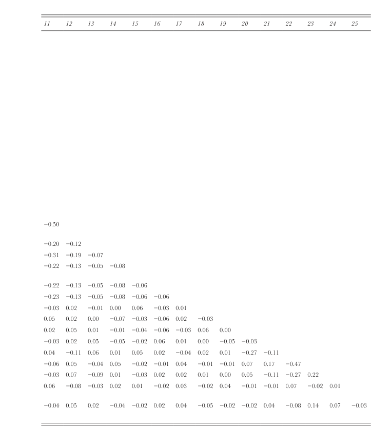

NOTE: figure/graphic rendered as an image from the PDF; its content is not machine-readable text. Caption (if any) follows as the next block.

**text found inside the figure**

*11 12 13 14 15 16 17 18 19 20 21 22 23 24 25*

−0.50

−0.20 −0.12

−0.31 −0.19 −0.07

−0.22 −0.13 −0.05 −0.08

−0.22 −0.13 −0.05 −0.08 −0.06

−0.23 −0.13 −0.05 −0.08 −0.06 −0.06

−0.03 0.02 −0.01 0.00 0.06 −0.03 0.01

0.05 0.02 0.00 −0.07 −0.03 −0.06 0.02 −0.03

0.02 0.05 0.01 −0.01 −0.04 −0.06 −0.03 0.06 0.00

−0.03 0.02 0.05 −0.05 −0.02 0.06 0.01 0.00 −0.05 −0.03

0.04 −0.11 0.06 0.01 0.05 0.02 −0.04 0.02 0.01 −0.27 −0.11

−0.06 0.05 −0.04 0.05 −0.02 −0.01 0.04 −0.01 −0.01 0.07 0.17 −0.47

−0.03 0.07 −0.09 0.01 −0.03 0.02 0.02 0.01 0.00 0.05 −0.11 −0.27 0.22

0.06 −0.08 −0.03 0.02 0.01 −0.02 0.03 −0.02 0.04 −0.01 −0.01 0.07 −0.02 0.01

−0.04 0.05 0.02 −0.04 −0.02 0.02 0.04 −0.05 −0.02 −0.02 0.04 −0.08 0.14 0.07 −0.03

Page 20

20 M. Brauer and L. Vandepoele

© 2023 Society for the Advancement of Management Studies and John Wiley & Sons Ltd.

Table IV. Results of fixed-effects regression analysis predicting investor response to workforce downsizing announcements

*Variables Model 1 Model 2 Model 3 Model 4 Model 5*

Impression offsetting 0.007*** 0.005***

(0.001) (0.001)

Strategic noise 0.003

(0.002)

Financial impression

offsetting

0.032*** 0.032***

(0.008) (0.009)

Operational impression

offsetting

0.019*** 0.020***

(0.005) (0.005)

Social impression offsetting 0.006 0.006

(0.005) (0.005)

Baseline positive

announcements

−0.006 −0.011** −0.009* −0.007 −0.009*

(0.004) (0.004) (0.004) (0.005) (0.004)

Neutral announcements 0.002 0.001 0.005 0.004

(0.004) (0.004) (0.003) (0.003)

Negative announcements −0.030*** −0.030*** −0.023** −0.024**

(0.007) (0.007) (0.008) (0.008)

Downsizing magnitude −0.234** −0.236** −0.264** −0.080 −0.077

(0.083) (0.083) (0.081) (0.091) (0.091)

Motive: Cost issues 0.001 −0.000 0.001 0.001 −0.001

(0.006) (0.006) (0.006) (0.012) (0.011)

Motive: Demand slump −0.009 −0.009 −0.010 0.008 0.008

(0.006) (0.006) (0.007) (0.011) (0.011)

Motive: M&A 0.010 0.008 0.004 0.009 0.008

(0.009) (0.009) (0.010) (0.015) (0.015)

Motive: Plant closing −0.001 −0.002 −0.001 0.004 0.002

(0.006) (0.006) (0.006) (0.011) (0.010)

Motive: Reorganization 0.005 0.004 0.004 0.007 0.004

(0.009) (0.009) (0.008) (0.011) (0.011)

Motive: Other −0.003 −0.004 −0.001 0.004 0.002

(0.009) (0.009) (0.009) (0.012) (0.012)

Friday announcement −0.003 −0.001 −0.003 0.000 0.003

(0.005) (0.005) (0.005) (0.005) (0.005)

Downsizing timing −0.001 −0.001 −0.004 0.006 0.006

(0.003) (0.003) (0.003) (0.005) (0.005)

Reactive downsizing −0.006* −0.006 −0.006 0.001 −0.000

(0.003) (0.003) (0.003) (0.004) (0.004)

(Continues)

Page 21

Managing the “Downside” of Downsizing 21

© 2023 Society for the Advancement of Management Studies and John Wiley & Sons Ltd.

in impression offsetting: While the number of common shares outstanding is related to how much media and investor attention a firm receives (e.g., Graffin et al., 2016), lower-tenured CEOs are more likely to engage in IM (e.g., Graffin et al., 2011; Whittington et al., 2016). Both of our instruments are strong predictors of impression offsetting (bCEOTenure = −0.018, p = 0.023; bSharesOutstanding = 0.150, p = 0.040), and are virtually uncorrelated with our dependent variable CAR (rCEOTenure = −0.02; rSharesOutstanding = 0.03). In the second stage, we re-ran our test of Hypothesis 2, including the corresponding residual from the first-stage regression. We then performed the Durbin–Wu–Hausman (DWH) test to check whether the estimates obtained by the second-stage regression were consistent with our previous results and the residuals were not significantly associated with our dependent variable CAR (Semadeni et al., 2014). We do not find any evidence for endogeneity (DWH = 1.41, p = 0.159), suggesting that the coefficients in our initial models are unbiased.

*Variables Model 1 Model 2 Model 3 Model 4 Model 5*

Firm size 0.002 0.002 0.002 0.002 0.002

(0.006) (0.006) (0.006) (0.007) (0.007)

Firm performance 0.033 0.021 0.043 0.038 0.018

(0.060) (0.061) (0.064) (0.065) (0.060)

Firm leverage −0.005 −0.005 −0.005 −0.006 −0.007

(0.005) (0.005) (0.005) (0.005) (0.005)

Firm diversification 0.003 0.001 0.005 0.043 0.041

(0.015) (0.015) (0.015) (0.024) (0.025)

Change in economic

conditions

0.001** 0.001** 0.001*** 0.001 0.001

(0.000) (0.000) (0.000) (0.001) (0.001)

Industry downsizing wave 0.006 0.006 0.004 0.024* 0.023*

(0.006) (0.007) (0.006) (0.010) (0.011)

Inverse Mills ratio −0.021 −0.021 −0.016 −0.014 −0.017

(0.016) (0.016) (0.016) (0.022) (0.022)

Constant 0.007 0.005 0.002 −0.048 −0.044

(0.079) (0.080) (0.086) (0.089) (0.090)

*N* 1449 1449 1449 569 569

*R<sup>2</sup>* 0.088 0.101 0.065 0.170 0.183

Adjusted *R<sup>2</sup>* 0.063 0.076 0.040 0.103 0.116

*F* 4.00*** 4.10*** 3.87*** 7.28*** 8.49***

*Note*: Year dummies included. Robust standard errors are provided in parentheses. Models 4 and 5 only include observations for which impression offsetting was present, as otherwise fractional variables for type of impression offsetting could not be derived. *p < 0.05; **p < 0.01; ***p < 0.001 (two-tailed tests).

Table IV. (Continued)

Page 22

22 M. Brauer and L. Vandepoele

© 2023 Society for the Advancement of Management Studies and John Wiley & Sons Ltd.

Hypothesis 3 stated that impression offsetting (i.e., the release of exclusively positive news items) is more effective than strategic noise (i.e., the release of confounding news of any kind) in attenuating investors’ negative response to a downsizing announcement. Model 3 of Table IV shows the results of the regression analysis including strategic noise. The relationship between strategic noise and CAR around downsizing announcements is positive but insignificant (b = 0.003, p = 0.075). To test whether the effect of impression offsetting on investor response is substantially greater than that strategic noise, we compared the coefficients of both variables using a Wald test. The effect of impression offsetting is significantly greater than that of strategic noise (χ2 = 6.98, p = 0.004), providing support for Hypothesis 3.

In Hypothesis 4, we reasoned that positive financial news items are most effective, positive operational news items are second most effective, and positive social news items are least effective in attenuating investors’ negative response to downsizing announcements. Model 4 of Table IV depicts the results of the regression analysis including fractional variables for all three types of impression offsetting. Both financial and operational impression offsetting are significantly positively related to CAR (bFinancial = 0.032, p = 0.000; bOperational = 0.019, p = 0.000), while the effect of social impression offsetting is positive but insignificant (bSo-

cial<sup>= 0.006, p = 0.214). We further tested the significance of the differences among these</sup> three impression offsetting types via Wald tests. While the difference between positive financial and operational news items is positive but insignificant (F = 2.03, p = 0.078), the difference between positive operational and social news items is positive and significant (F = 4.89, p = 0.015), thereby partially supporting Hypothesis 4. Specifically, our results indicate that a firm which raises the share of positive *financial* news around downsizing by 10 per cent can increase the CAR to its downsizing announcement by 0.32 per cent. In terms of market value, this translates to a wealth effect of $234 million. In comparison, a 10 per cent increase in the share of positive *operational* news is associated with an increase in CAR of 0.19 per cent which corresponds to a $140 million higher market value.

Model 5 of Table IV shows the full model. The effects reported above remain consistent. We find that impression offsetting (b = 0.005, p = 0.001) as well as both the share of financial and operational impression offsetting (bFinancial = 0.032, p = 0.000; bOpera-

tional<sup>= 0.020, p = 0.000) are significantly positively associated with CAR around work</sup>force downsizing announcements.

#### **Isolating Impression Offsetting’s Attention Dilution and Mental Averaging Effects**

We conducted additional empirical analyses to carve out the relative extents to which attention dilution and mental averaging contribute to impression offsetting’s effect and corroborate our finding that mental averaging is the more powerful mechanism by which impression offsetting affects investor response.<sup>[</sup><sup>4</sup><sup>]</sup> To do so, we isolated the positive effect of mental averaging (i.e., the effect of positive news as if it was not released simultaneously to a downsizing) on investor response and the negative effect of downsizing on investor response (i.e., CAR). We use isolated instances of positive news during the baseline window to assess the *expected* CAR to positive news issued by our sample firms around downsizing announcements (i.e., the mental averaging effect). Next, we derive the *expected* CAR to downsizing using isolated downsizing

Page 23

Managing the “Downside” of Downsizing 23

© 2023 Society for the Advancement of Management Studies and John Wiley & Sons Ltd.

announcements in our sample which were not confounded by any other news items. On average, we find that the mental averaging effect results in a positive ‘uplift’ in CAR of 0.91 per cent and that the CAR to isolated downsizing announcements equals −0.76 per cent. To assess impression offsetting’s attention dilution effect, we calculate the difference between the *actual* CAR to downsizing announcements around which firms used impression offsetting (i.e., 0.48 per cent on average) and the sum of the *expected* CARs to isolated positive news and downsizing announcements. We find that, on average, only 0.33 per cent of the overall effect of impression offsetting can be attributed to the attention dilution effect (t = 1.61, p = 0.054). Finally, we conducted a paired *t*-test to examine whether the increase in CAR due to mental averaging is greater than the increase in CAR due to attention dilution. The difference is statistically significant (t = 2.37, p = 0.009), providing additional support for Hypothesis 3.

In addition to these isolating analyses, we estimated impression offsetting’s attention dilution effect using a matching approach. Specifically, we created a new dataset including two data points for each downsizing announcement: one with the *actual* CAR around the downsizing announcement and one with the sum of the *expected* CARs we derived from isolated instances of positive news releases in the baseline window and isolated downsizing announcements. We then re-ran our regression analyses including a dummy variable for the actual downsizing announcement and the interaction term between this dummy variable and impression offsetting. Consistent with our results reported above, we find that the coefficient of the interaction term is positive (b = 0.003, p = 0.087). This further suggests that attention dilution is only a minor explanatory factor for the effect of impression offsetting, whereas mental averaging is the more powerful causal mechanism.

Finally, we conducted further analyses to isolate impression offsetting’s attention dilution effect by comparing downsizings of different sizes. For this analysis, we assume that impression offsetting’s mental averaging effect is constant for downsizings of any size. Hence, if impression offsetting’s effect were to increase with downsizing magnitude, this would indicate that impression offsetting also dilutes investors’ attention. Indeed, we find that downsizing magnitude amplifies the effect of impression offsetting on investor response, as the coefficient of the interaction term is positive and significant (b = 0.114, p = 0.026). Interestingly, we further find that downsizing magnitude does not amplify the effects of all types of positive news: The coefficients of the interaction terms between downsizing magnitude and both positive financial and operational news are positive and significant (bFinancial = 0.415, p = 0.031; bOpera-

tional<sup>= 0.246, p = 0.038). The coefficient of the interaction term between downsizing</sup> magnitude and positive social news is not (b = 0.021, p = 0.787). Collectively, these results provide additional support for the fact that the attention dilution mechanism is actually operative and further suggest that attention dilution is primarily driven by positive financial and operational news.

#### **Supplementary Analyses**

Page 24

24 M. Brauer and L. Vandepoele

© 2023 Society for the Advancement of Management Studies and John Wiley & Sons Ltd.

Table V. Supplementary robustness checks: Effect of impression offsetting over alternative event windows

*Variables Day 0 Day 0 to +1 Day –1 to +2 Day –2 to +2 Day –3 to +3*

Impression offsetting 0.004*** 0.005*** 0.008*** 0.007*** 0.008***

(0.001) (0.001) (0.002) (0.002) (0.002)

Control variables Yes Yes Yes Yes Yes

Year dummies Yes Yes Yes Yes Yes

*N* 1449 1449 1449 1449 1449

*R<sup>2</sup>* 0.097 0.073 0.085 0.103 0.090

Adjusted *R<sup>2</sup>* 0.071 0.047 0.059 0.078 0.064

*F* 4.45*** 2.96*** 4.16*** 4.63*** 8.88***

*Note*: Robust standard errors are provided in parentheses. *p < 0.05; **p < 0.01; ***p < 0.001 (two-tailed tests).

Table VI. Supplementary robustness checks: Effect of the type of impression offsetting over alternative event windows

*Variables Day 0 Day 0 to +1*

*Day –1 to +2*

*Day –2 to +2*

*Day –3 to +3*

Financial impression offsetting 0.026** 0.030** 0.029** 0.035** 0.035**

(0.009) (0.009) (0.010) (0.011) (0.013)

Operational impression offsetting 0.007 0.011* 0.020*** 0.021*** 0.018*

(0.004) (0.004) (0.005) (0.006) (0.008)

Social impression offsetting 0.005 0.002 –0.001 –0.002 –0.003

(0.004) (0.005) (0.007) (0.008) (0.010)

Control variables Yes Yes Yes Yes Yes

Year dummies Yes Yes Yes Yes Yes

*N* 569 569 569 569 569

*R<sup>2</sup>* 0.131 0.111 0.181 0.197 0.169

Adjusted *R<sup>2</sup>* 0.062 0.040 0.116 0.132 0.103

*F* 3.47*** 4.92*** 9.82*** 11.30*** 8.34***

*Note*: Robust standard errors are provided in parentheses. *p < 0.05; **p < 0.01; ***p < 0.001 (two-tailed tests).

Page 25

Managing the “Downside” of Downsizing 25

© 2023 Society for the Advancement of Management Studies and John Wiley & Sons Ltd.

Second, we checked whether impression offsetting is associated with decreasing marginal benefits. To do so, we examined a possible inverted U-shaped effect of impression offsetting on investor response employing the procedure outlined by Haans et al. (2016). However, we do not find evidence for a non-linear relationship. The squared term for the extent of impression offsetting and a *t*-test for the presence of an inverse U-shape are both insignificant (b = −0.000, p = 0.222; t = 0.12, p = 0.452). Moreover, we investigated whether the repeated use of impression offsetting reduces its positive influence on investor response. Interestingly, when we measure prior use of impression offsetting in the three years before a downsizing via a dummy variable, we find that prior use of impression offsetting negatively moderates the positive relationship between impression offsetting and CAR (b = −0.008, p = 0.028). This suggests that impression offsetting’s effect may wear off with repeated use. However, when we measure prior use of impression offsetting via a count variable, we do not observe a significant interaction effect anymore (b = 0.000, p = 0.432).

Third, we analysed the insignificant effect of firm performance on the likelihood of downsizing in our first-stage Heckman model in greater detail. Consistent with prior downsizing studies, the effect of firm performance becomes significant (b = −0.899, p = 0.018) when we remove total shareholder return and firm leverage as control variables. Moreover, when we use a dummy variable indicating if ROA declined in the previous fiscal year, we find that a performance decline is a significant predictor of downsizing (b = 0.244, p = 0.033). Consistent with the most recent study by Cascio et al. (2021), we also find that industry-adjusted changes in a firm’s net income are negatively associated with the likelihood of downsizing (b = −0.231, p = 0.000).

Fourth, we examined the sensitivity of our results through alternative operationalizations of impression offsetting. Specifically, we used a dummy variable to indicate the use of impression offsetting, the natural logarithm of the count of impression offsetting releases, and different cut-offs for impression offsetting at a count of two, three, four, and five positive press releases. Our results remain consistent for all these different operationalizations. In addition, we employed different operationalizations for our impression offsetting type variables. Again, our results remain fully consistent when we use dummy or count variables instead of fractional variables to measure financial, operational, and social impression offsetting. Moreover, we performed sub-sample analyses to rule out alternative explanations. Specifically, we tested whether impression offsetting’s impact is epiphenomenal and only the by-product of the impact of other confounding news. To do so, we compared the CAR to downsizing announcements with any positive, neutral, or negative confounding news to the CAR to downsizing announcements without any confounding news using a paired *t*-test. The difference in CAR across the two samples was not significant (t = 0.64, p = 0.262), suggesting that the effect of impression offsetting is not epiphenomenal and not driven by the presence of other confounding news. Finally, we checked whether our findings change when we only include larger downsizings (i.e., when at least 0.5 per cent, 1 per cent, 2 per cent, or 3 per cent of a firm’s workforce were laid off) or when we only include reactive or proactive downsizings in our analyses. The empirical results for all hypotheses remain fully consistent.

Page 26

26 M. Brauer and L. Vandepoele

© 2023 Society for the Advancement of Management Studies and John Wiley & Sons Ltd.

#### **DISCUSSION AND IMPLICATIONS**

#### **Theoretical Implications**

Our study holds several key implications for IM theory and literature on workforce downsizing. First, we contribute to research on organizational IM for financial markets (e.g., Busenbark et al., 2017; Hayward and Fitza, 2017; Lamin and Zaheer, 2012; Pan et al., 2018; Washburn and Bromiley, 2014; Westphal and Graebner, 2010; Whittington et al., 2016). While research in this field has generated valuable insights on how firms can influence investors and analysts using IM, prior work set in the context of negative events has mostly explored reactive tactics (e.g., Lamin and Zaheer, 2012). In contrast, we add to the emerging research stream on anticipatory IM which examines organizational influence tactics that are used in anticipation of negative investor response and intend to placate investors (Busenbark et al., 2017; Graffin et al., 2016).

Our study is (incrementally) original, as we are first to reason why firms can be expected to utilize impression offsetting around workforce downsizing and first to show that impression offsetting attenuates investors’ negative response to downsizing. The only prior study on the effect of impression offsetting by Graffin et al. (2016) has explored impression offsetting in the context of acquisitions. Given that workforce reductions are perceived significantly more negatively by investors than acquisitions (Datta and Basuil, 2015; Datta et al., 2010, 2012; Moeller et al., 2005), it is theoretically non-obvious whether impression offsetting is also efficacious in this context. By showing that the attenuating effect of impression offsetting extends to the context of workforce reductions, our study is thus not only responsive to calls by IM scholars to ‘examine the use of IM behaviors outside the commonly researched contexts of job interviews and performance appraisals’ (Bolino et al., 2008, p. 1090), but also expands the cumulative body of research knowledge on the use and effectiveness of impression offsetting. According to Bettis et al. (2016), such quasi-replications have significant scientific utility if our theoretical knowledge is grounded on a single study or less than a handful of studies, as is the case for impression offsetting. Our study also makes an incremental contribution to the growing research stream on strategic noise (Graffin et al., 2011; Jin et al., 2022). By examining the effectiveness of strategic noise in the context of downsizing, we complement prior strategic noise studies which have exclusively focused on the antecedents of firms’ use of strategic noise (Graffin et al., 2011; Jin et al., 2022). Our results show that strategic noise is less effective than impression offsetting in attenuating the negative investor response to downsizing. Thereby, our study empirically corroborates that strategic noise and impression offsetting affect investors through different mechanisms as proposed by Graffin et al. (2016).

Second, our study provides novel theoretical insights by unpacking *why* and *how* impression offsetting can effectively attenuate negative investor perceptions. Prior studies on impression offsetting have theorized that impression offsetting affects audience perceptions by diluting the audience’s attention and by forcing the audience to mentally average positive and negative news (Gamache et al., 2019; Graffin et al., 2016), but have left unexamined whether in fact both causal mechanisms are operative, and

Page 27

Managing the “Downside” of Downsizing 27

© 2023 Society for the Advancement of Management Studies and John Wiley & Sons Ltd.

which one is more powerful. Our study takes an important first step to answer this question by theorizing and empirically showing that mental averaging is the salient causal mechanism explaining impression offsetting’s effectiveness. Attention dilution is also found to contribute to the overall effect but to a much lesser degree. By being the first to reveal that both causal mechanisms are operative, our work augments our understanding of why impression offsetting is an effective influence tactic towards investors. Supplementary sub-sample analyses, which help isolate the individual effects of attention dilution and mental averaging and help rule out alternative explanations, offer further support for this proposition. Specifically, these sub-sample analyses suggest that the influence of mental averaging (CAR 0.91 per cent) is roughly three times higher than the influence of attention dilution on investor response (CAR 0.33 per cent).

An additional revelatory insight generated by our study for IM theory is that not all positive information has the same marginal utility. We challenge and extend existing theory on impression offsetting by distinguishing between different types of positive information. Prior studies on impression offsetting have assumed that all types of positive news are received equally by investors (Gamache et al., 2019; Graffin et al., 2016). Our study departs from this assumption and reveals that impression offsetting’s effectiveness differs by the type of positive news released by a firm. Our findings suggest that investors’ cognitive schemas affect the extent to which they attribute importance to different types of positive news. Specifically, empirical results show that substantive positive financial and operational news are most effective in diluting investors’ attention and in provoking a more balanced reading of downsizing firms’ prospects. The insight that the ‘composition of impression offsetting’ matters enhances our general understanding of ‘why attempts at IM might succeed or fail’ (Bolino et al., 2008, p. 1099) and hints at the importance of audience-specific characteristics for the effectiveness of IM. Thereby, our study complements prior work on IM for financial markets which found that metaphorical language is less effective towards managing the impressions of security analysts compared with the media (König et al., 2018).

Third, our study contributes to workforce downsizing literature. Our work is (incrementally) original, as we are among the first to apply an IM perspective to workforce downsizing. Past studies have found strong empirical evidence for a negative investor response to downsizing (Datta and Basuil, 2015; Datta et al., 2010, 2012) and have recognized the importance of firm communication to influence investor response (Datta et al., 2010). Yet, whether and to which effect downsizing firms use communicative influence tactics to attenuate investors’ negative response has been left largely unexamined except for a single study in accounting and finance (Nègre et al., 2017). We extend knowledge on this very issue by exploring the use and effectiveness of impression offsetting, an anticipatory IM tactic, whereas Nègre et al. (2017) examined the influence tactic of justification, a reactive IM tactic. Due to this difference in focus, the theoretical reasoning and implications are very different across both studies. Specifically, Nègre et al. (2017) posit that investors will react less negatively when firms explain and justify the downsizing. Yet, they find that firms’ press releases on a downsizing in fact *amplify* negative investor response. Counter to prior downsizing studies which found that proactive downsizing is received less negatively by investors (e.g., Hillier et al., 2007; Palmon

Page 28

28 M. Brauer and L. Vandepoele

© 2023 Society for the Advancement of Management Studies and John Wiley & Sons Ltd.

et al., 1997), they further argue and find that justifying downsizing by means of proactive arguments *amplifies* investors’ negative response. Nègre et al. (2017) explain this effect by arguing that a firm’s justification attempt by means of proactive arguments makes the downsizing appear less legitimate and less ethical. By contrast, our study shows that anticipatory IM in form of impression offsetting can effectively *attenuate* the negative impact of a downsizing announcement primarily by forcing investors to mentally average positive and negative news. Hence, the implications that can be drawn from both studies regarding the effectiveness of organizational IM tactics are vastly different. While Nègre et al.’s (2017) study cautions that reactive justification or reframing of the downsizing can backfire, our work is the first to identify an IM tactic that can effectively cushion investors’ negative response.

#### **Practical Implications**

Knowledge on how to effectively manage workforce downsizing is of high practical relevance. In response to the Covid pandemic, the ‘tech crunch’, and recession fears, more than half of US firms currently consider substantial workforce cuts (Wilding, 2022). Our study suggests that firms can reduce the ‘downside’ of downsizing in form of a negative investor response by releasing positive news around a workforce downsizing announcement. Importantly, we find that this attenuating effect is economically substantive: Impression offsetting reduces investors’ negative response by 0.66 per cent which, on average, translates to a $490 million preservation in market value for our sample firms. Further, our findings highlight that the release of positive financial and operational news seems to be a particularly effective way to appease investors and provoke a more balanced reading of the firm’s prospects. At the same time, selected results from our supplementary analyses caution that impression offsetting is not a panacea: When used repeatedly, the attenuating effect of impression offsetting seems to wear off. Our work also has practical implications for investors. Specifically, our findings on the use and effectiveness of impression offsetting suggest that investors should be sensitive of firms’ IM attempts – particularly around events that are likely to elicit negative investor response, such as workforce downsizing. Thus, investors should interpret firms’ press releases around workforce downsizing and other negative events with caution, as news could be deliberately disseminated by the focal firm to bias investors’ assessment.

#### **Limitations and Avenues for Future Research**

Our study focuses exclusively on workforce downsizings by the 250 largest publicly listed US firms, and thus does not include or reflect the full variability in firm size among US firms. Hence, we see merit in future research which tests whether our findings also hold for small- and mid-sized firms. Similarly, we see the need to validate our findings in different institutional contexts. Drawing on a sample of 227 downsizings by 119 public French firms, the study by Nègre et al. (2017), as outlined above, indicates that IM attempts may prove not only ineffective but even harmful in institutional contexts with strict dismissal regulation. Further, investors could potentially respond differently to downsizing announcements in emerging economies because of different – e.g., more egalitarian – cultural norms and

Page 29

Managing the “Downside” of Downsizing 29

© 2023 Society for the Advancement of Management Studies and John Wiley & Sons Ltd.

other institutional factors. Moreover, we see merit in future studies that examine whether not only investor response but also the response of other relevant audiences (e.g., employees, customers) is contingent on the composition of impression offsetting.

Like prior works on organizational IM (e.g., Graffin et al., 2011, 2016; Hayward and Fitza, 2017), our study also cannot unambiguously determine whether downsizing firms intentionally or rather unintentionally engage in impression offsetting. However, the fact that the downsizing firms in our sample issue about twice as many positive news releases around downsizing announcements than is indicated by their baseline count of positive news releases strongly suggests that there is agency behind the issuance of positive news around downsizing announcements.

Finally, an intriguing phenomenon in today’s ‘downsizing wave’ is that some firms (e.g., Amazon, Meta) engage in multiple downsizings in relatively short time intervals. Thus, we see merit in future studies which shed light on the question of whether these ‘serial downsizers’ learn to communicate their downsizing announcements more effectively. Such research endeavours could also shed further light on whether the effect of impression offsetting wears off when used repeatedly. Our supplementary analysis on the repeated use of impression offsetting provides first indication of a waning effect. Overall, a more detailed examination of differences between ‘serial downsizers’ and differences when it comes to the ‘serial use’ of IM tactics thus seems to have both high theoretical and practical utility.

#### **ACKNOWLEDGMENTS**

We are grateful to Associate Editor Yuliya Snihur and the three anonymous reviewers for their constructive comments and guidance.

#### **NOTES**

[1] By definition, our sample excludes all other firms that were not part of the *Fortune* 250 in 2001, and thus

does not include or reflect the full variability in firm size among US firms. Moreover, private firms (e.g., Publix Super Markets, State Farm Insurance) were excluded from the sample, since stock market data was missing to assess investor response. [2] We used a three-month baseline window because the manual coding effort for a 12-month baseline

window would be excessive while providing little added value. Graffin et al. (2016) report that results for both windows correlate strongly (r = 0.87). [3] The mean number of positive three-day baseline positive announcements is calculated as follows:

[9.411 × 3]/63, with 9.411 being the overall average count of our sample firms’ positive press releases for all baseline periods, 3 the number of days in the event window, and 63 the number of business days in the three-month period. [4] We thank an anonymous reviewer for suggesting these supplementary analyses.

#### **REFERENCES**

Aguinis, H., Gottfredson, R. K. and Joo, H. (2013). ‘Best-practice recommendations for defining, identifying,

and handling outliers’. *Organizational Research Methods*, **16**, 270–301. Akhtar, S., Faff, R., Oliver, B. and Subrahmanyam, A. (2011). ‘The power of bad: The negativity bias in

Australian consumer sentiment announcements on stock returns’. *Journal of Banking & Finance*, **35**, 1239–49. Amabile, T. M. and Conti, R. (1999). ‘Changes in the work environment for creativity during downsizing’.

*Academy of Management Journal*, **42**, 630–40. Baker, M. and Wurgler, J. (2007). ‘Investor sentiment in the stock market’. *Journal of Economic Perspectives*, **21**,

129–51.

Page 30

30 M. Brauer and L. Vandepoele

© 2023 Society for the Advancement of Management Studies and John Wiley & Sons Ltd.

Baum, C. F. (2001). ‘Residual diagnostics for cross-section time series regression models’. *The Stata Journal*,

**1**, 101–04. Bergman, N. K. and Roychowdhury, S. (2008). ‘Investor sentiment and corporate disclosure’. *Journal of*

*Accounting Research*, **46**, 1057–83. Bettis, R. A., Helfat, C. E. and Shaver, J. M. (2016). ‘The necessity, logic, and forms of replication’. *Strategic*

*Management Journal*, **37**, 2193–203. Bolino, M., Kacmar, K. M., Turnley, W. H. and Gilstrap, J. B. (2008). ‘A multi-level review of impression

management motives and behaviors’. *Journal of Management*, **34**, 1080–109. Bolino, M., Long, D. and Turnley, W. H. (2016). ‘Impression management in organizations: Critical ques-

tions, answers, and areas for future research’. *Annual Review of Organizational Psychology and Organizational Behavior*, **3**, 377–406. Brauer, M. and Laamanen, T. (2014). ‘Workforce downsizing and firm performance: An organizational

routine perspective’. *Journal of Management Studies*, **51**, 1311–33. Brauer, M. and Wiersema, M. (2018). ‘Analyzing analyst research: A review of past coverage and recommen-

dations for future research’. *Journal of Management*, **44**, 218–48. Brauer, M. and Zimmermann, M. (2019). ‘Investor response to workforce downsizing: The influence

of industry waves, macroeconomic outlook, and firm performance’. *Journal of Management*, **45**, 1775–801. Brealey, R. and Myers, S. (1984). *Principles of Corporate Finance*. New York: McGraw-Hill. Brockner, J., Spreitzer, G., Mishra, A., Hochwarter, W., Pepper, L. and Weinberg, J. (2004). ‘Perceived con-

trol as an antidote to the negative effects of layoffs on survivors’ organizational commitment and job performance’. *Administrative Science Quarterly*, **49**, 76–100. Budros, A. (1997). ‘The new capitalism and organizational rationality: The adoption of downsizing pro-

grams, 1979–1994’. *Social Forces*, **76**, 229–50. Busenbark, J. R., Lange, D. and Certo, S. T. (2017). ‘Foreshadowing as impression management: Iluminating

the path for security analysts’. *Strategic Management Journal*, **38**, 2486–507. Bushard, B. (2023). *2023 Layoff Tracker: Meta Cuts 10,000 Employees*. Available at: https://www.forbes.com/

(accessed 9 August 2023). Business Wire. (2012a). *Cigna Reports Strong Third Quarter Results and Raises 2012 Outlook*. Available at: https://

www.businesswire.com/news/ (accessed 9 August 2023). Business Wire. (2012b). *Verizon Wireless Enhances 4G LTE Network Coverage in Windsor Locks, Connecticut*. Available

at: https://www.businesswire.com/news/ (accessed 9 August 2023). Business Wire. (2012c). *Verizon Wireless Enhances 4G LTE Network Coverage in Southeastern Massachusetts*. Available

at: https://www.businesswire.com/news/ (accessed 9 August 2023). Cagle, J. A. B., Sen, A. and Pawlukiewicz, J. E. (2009). ‘Inter-industry differences in layoff announcement

effects for financial institutions’. *Journal of Economics & Finance*, **33**, 100–10. Cascio, W. F. (1993). ‘Downsizing: What do we know? What have we learned?’. *Academy of Management*

*Executive*, **7**, 95–104. Cascio, W. F., Chatrath, A. and Christie-David, R. A. (2021). ‘Antecedents and consequences of employee

and asset restructuring’. *Academy of Management Journal*, **64**, 587–613. Certo, S. T., Busenbark, J. R., Woo, H. S. and Semadeni, M. (2016). ‘Sample selection bias and Heckman

models in strategic management research’. *Strategic Management Journal*, **37**, 2639–57. Certo, S. T. and Semadeni, M. (2006). ‘Strategy research and panel data: Evidence and implications’. *Journal*

*of Management*, **32**, 449–71. Chatterjee, S. and Hadi, A. S. (2012). *Regression Analysis by Example*, 5th edition. Hoboken, NJ: John Wiley &

Sons. Chen, P., Mehrotra, V., Sivakumar, R. and Yu, W. W. (2001). ‘Layoffs, shareholders’ wealth, and corporate

performance’. *Journal of Empirical Finance*, **8**, 171–99. Christiansen, C., Eriksen, J. N. and Møller, S. V. (2014). ‘Forecasting US recessions: The role of sentiment’.

*Journal of Banking & Finance*, **49**, 459–68. Datta, D. K. and Basuil, D. A. (2015). ‘Does employee downsizing really work?’ In Andresen M. and Nowak

C. (Eds), *Human Resource Management Practices*. Springer International: Cham, 197–221. Datta, D. K., Basuil, D. and Radeva, E. A. (2012). ‘Employee downsizing and organizational performance:

What do we know?’ In Cooper G., Pandey A. and Quick J. (Eds), *Downsizing: Is Less Still More?* New York: Cambridge University Press, 199–227. Datta, D. K., Guthrie, J. P., Basuil, D. and Pandey, A. (2010). ‘Causes and effects of employee downsizing: A

review and synthesis’. *Journal of Management*, **36**, 281–348.

Page 31

Managing the “Downside” of Downsizing 31

© 2023 Society for the Advancement of Management Studies and John Wiley & Sons Ltd.

DellaVigna, S. and Pollet, J. M. (2009). ‘Investor inattention and Friday earnings announcements’. *The*

*Journal of Finance*, **64**, 709–49. Dlouhy, K. and Casper, A. (2021). ‘Downsizing and surviving employees’ engagement and strain: The role

of job resources and job demands’. *Human Resource Management*, **60**, 435–54. Elayan, F. A., Swales, G. S., Maris, B. A. and Scott, J. R. (1998). ‘Market reactions, characteristics, and the

effectiveness of corporate layoffs’. *Journal of Business Finance & Accounting*, **25**, 329–51. Elsbach, K. D., Sutton, R. I. and Principe, K. E. (1998). ‘Averting expected challenges through anticipatory

impression management: A study of hospital billing’. *Organization Science*, **9**, 68–86. Farber, H. S. and Hallock, K. F. (2009). ‘The changing relationship between job loss announcements and

stock prices: 1970–1999’. *Labour Economics*, **16**, 1–11. Fiske, S. T. and Taylor, S. E. (2017). *Social Cognition: From Brains to Culture*, 3rd edition. London: SAGE

Publications. Flanagan, D. J. and O’Shaughnessy, K. C. (2005). ‘The effects of layoffs on firm reputation’. *Journal of*

*Management*, **31**, 445–63. Gamache, D. L., McNamara, G., Graffin, S. D., Kiley, J., Haleblian, J. and Devers, C. E. (2019). ‘Impression

offsetting as an early warning signal of low CEO confidence in acquisitions’. *Academy of Management Journal*, **62**, 1307–32. Gardner, W. L. and Martinko, M. J. (1988). ‘Impression management in organizations’. *Journal of Management*,

**14**, 321–38. Godfrey, P. C., Merrill, C. B. and Hansen, J. M. (2009). ‘The relationship between corporate social responsi-

bility and shareholder value: An empirical test of the risk management hypothesis’. *Strategic Management Journal*, **30**, 425–45. Goffman, E. (1959). *The Presentation of Self in Everyday Life*. Garden City, NY: Doubleday Anchor. Graffin, S. D., Carpenter, M. A. and Boivie, S. (2011). ‘What’s all that (strategic) noise? Anticipatory impres-

sion management in CEO succession’. *Strategic Management Journal*, **32**, 748–70. Graffin, S. D., Haleblian, J. and Kiley, J. T. (2016). ‘Ready, AIM, acquire: Impression offsetting and acquisi-

tions’. *Academy of Management Journal*, **59**, 232–52. Haans, R. F. J., Pieters, C. and He, Z.-L. (2016). ‘Thinking about U: Theorizing and testing U- and inverted

U-shaped relationships in strategy research’. *Strategic Management Journal*, **37**, 1177–95. Hayes, A. F. and Krippendorff, K. (2007). ‘Answering the call for a standard reliability measure for coding

data’. *Communication Methods and Measures*, **1**, 77–89. Hayward, M. L. A. and Fitza, M. A. (2017). ‘Pseudo-precision? Precise forecasts and impression manage-

ment in managerial earnings forecasts’. *Academy of Management Journal*, **60**, 1094–116. Hillier, D., Marshall, A., McColgan, P. and Werema, S. (2007). ‘Employee layoffs, shareholder wealth and

firm performance: Evidence from the UK’. *Journal of Business Finance & Accounting*, **34**, 467–94. Homburg, C., Klarmann, M. and Staritz, S. (2012). ‘Customer uncertainty following downsizing: The ef-

fects of extent of downsizing and open communication’. *Journal of Marketing*, **76**, 112–29. Hou, K. and Robinson, D. (2006). ‘Industry concentration and average stock returns’. *The Journal of Finance*,

**61**, 1927–56. Jin, J., Li, H. and Hoskisson, R. (2022). ‘The use of strategic noise in reactive impression management: How

do market reactions matter?’ *Academy of Management Journal*, **65**, 1303–26. Kahneman, D. (1973). *Attention and Effort*. Englewood Cliffs, NJ: Prentice-Hall. König, A., Mammen, J., Luger, J., Fehn, A. and Enders, A. (2018). ‘Silver bullet or ricochet? CEOs’ use

of metaphorical communication and infomediaries’ evaluations’. *Academy of Management Journal*, **61**, 1196–230. Kuhnen, C. M. (2015). ‘Asymmetric learning from financial information’. *The Journal of Finance*, **70**,

2029–62. Lamin, A. and Zaheer, S. (2012). ‘Wall street vs. main street: Firm strategies for defending legitimacy and

their impact on different stakeholders’. *Organization Science*, **23**, 47–66. Lee, P. M. (1997). ‘A comparative analysis of layoff announcements and stock price reactions in the United

States and Japan’. *Strategic Management Journal*, **18**, 879–94. Lin, J. C. and Rozeff, M. S. (1993). ‘Capital market behavior and operational announcements of layoffs,

operation closings, and pay cuts’. *Review of Quantitative Finance and Accounting*, **3**, 29–45. Love, G. E. and Kraatz, M. (2009). ‘Character, conformity, or the bottom line? How and why downsizing

affected corporate reputation’. *Academy of Management Journal*, **52**, 314–35. Marshall, A., McColgan, P. and McLeish, S. (2012). ‘Why do stock prices decline in response to employee

layoffs? UK evidence from the 2008 global financial crisis’. *Journal of Financial Research*, **35**, 375–96.

Page 32

32 M. Brauer and L. Vandepoele

© 2023 Society for the Advancement of Management Studies and John Wiley & Sons Ltd.

McKinley, W., Zhao, J. and Rust, K. G. (2000). ‘A sociocognitive interpretation of organizational downsiz-

ing’. *Academy of Management Review*, **25**, 227–43. McWilliams, A. and Siegel, D. (1997). ‘Event studies in management research: Theoretical and empirical

issues’. *Academy of Management Journal*, **40**, 626–57. Moeller, S. B., Schlingemann, F. P. and Stulz, R. M. (2005). ‘Wealth destruction on a massive scale? A study

of acquiring-firm returns in the recent merger wave’. *The Journal of Finance*, **60**, 757–82. Nègre, E., Verdier, M. A., Cho, C. H. and Patten, D. M. (2017). ‘Disclosure strategies and investor reac-

tions to downsizing announcements: A legitimacy perspective’. *Journal of Accounting and Public Policy*, **36**, 239–57. Neuhierl, A., Scherbina, A. and Schlusche, B. (2013). ‘Market reaction to corporate press releases’. *Journal of*

*Financial and Quantitative Analysis*, **48**, 1207–40. Nixon, R. D., Hitt, M. A., Lee, H. and Jeong, E. (2004). ‘Market reactions to announcements of corporate

downsizing actions and implementation strategies’. *Strategic Management Journal*, **25**, 1121–29. Ocasio, W. (1997). ‘Towards an attention-based view of the firm’. *Strategic Management Journal*, **18**,

187–206. Ocasio, W. (2011). ‘Attention to attention’. *Organization Science*, **22**, 1286–96. Palmon, O., Sun, H.-L. and Tang, A. P. (1997). ‘Layoff announcements: Stock market impact and financial

performance’. *Financial Management*, **26**, 54–68. Pan, L., McNamara, G., Lee, J. J., Haleblian, J. and Devers, C. E. (2018). ‘Give it to us straight (most of the

time): Top managers’ use of concrete language and its effect on investor reactions’. *Strategic Management Journal*, **39**, 2204–25. PR Newswire. (2009a). *Microsoft Helps Schools Embrace 21st-century Opportunities and Challenges*. Available at:

https://www.prnewswire.com/news-releases/ (accessed 9 August 2023). PR Newswire. (2009b). *Microsoft Encourages Families to Get Game Smart*. Available at: https://www.prnewswire.

com/news-releases/ (accessed 9 August 2023). Robinson, S. L., Kraatz, M. S. and Rousseau, D. M. (1994). ‘Changing obligations and the psychological

contract: A longitudinal study’. *Academy of Management Journal*, **37**, 137–52. Sayrs, L. W. (1989). *Pooled Time Series Analysis*. Newbury Park, CA: SAGE Publications. Schlenker, B. R. (1980). *Impression Management: The Self-Concept, Social Identity, and Interpersonal Relations*.

Monterey, CA: Brooks/Cole. Schulz, A. C. and Himme, A. (2022). ‘Stock market reactions to downsizing announcements: An analysis

through an institutional lens’. *Socio-Economic Review*, **20**, 1825–55. Semadeni, M., Withers, M. C. and Certo, S. T. (2014). ‘The perils of endogeneity and instrumental

variables in strategy research: Understanding through simulations’. *Strategic Management Journal*, **35**, 1070–79. Shah, P. P. (2000). ‘Network destruction: The structural implications of downsizing’. *Academy of Management*

*Journal*, **43**, 101–12. Shepherd, D. A. and Williams, T. A. (2018). ‘Hitting rock bottom after job loss: Bouncing back to create a

new positive work identity’. *Academy of Management Review*, **43**, 28–49. Spreitzer, G. M. and Mishra, A. K. (2002). ‘To stay or to go: Voluntary survivor turnover following an orga-

nizational downsizing’. *Journal of Organizational Behavior*, **23**, 707–29. Trevor, C. O. and Nyberg, A. J. (2008). ‘Keeping your headcount when all about you are losing theirs:

Downsizing, voluntary turnover rates, and the moderating role of HR practices’. *Academy of Management Journal*, **51**, 259–76. Washburn, M. and Bromiley, P. (2014). ‘Managers and analysts: An examination of mutual influence’.

*Academy of Management Journal*, **57**, 849–68. Westphal, J. D. and Clement, M. B. (2008). ‘Sociopolitical dynamics in relations between top managers

and security analysts: Favor rendering, reciprocity, and analyst stock recommendations’. *Academy of Management Journal*, **51**, 873–97. Westphal, J. D. and Graebner, M. E. (2010). ‘A matter of appearances: How corporate leaders manage the

impressions of financial analysts about the conduct of their boards’. *Academy of Management Journal*, **53**, 15–44. Whittington, R., Yakis-Douglas, B. and Ahn, K. (2016). ‘Cheap talk? Strategy presentations as a form of

chief executive officer impression management’. *Strategic Management Journal*, **37**, 2413–24. Wilding, M. (2022). *How to Deal With Layoff Anxiety*. Available at: https://hbr.org/2022/09/how-to-deal-

with-layoff-anxiety (accessed 9 August 2023). Wooldridge, J. M. (2010). *Econometric Analysis of Cross Section and Panel Data*, 2nd edition. Cambridge, MA:

The MIT Press.

Page 33

Managing the “Downside” of Downsizing 33

© 2023 Society for the Advancement of Management Studies and John Wiley & Sons Ltd.

Worrell, D. L., Davidson, W. N. and Sharma, V. M. (1991). ‘Layoff announcements and stockholder wealth’.

*Academy of Management Journal*, **34**, 662–78. Zyglidopoulos, S. C. (2005). ‘The impact of downsizing on corporate reputation’. *British Journal of Management*,

**16**, 253–59.

#### **APPENDIX Categorization of press releases in the event window**

*Category Positive Neutral Negative Total*

Earnings release 43 38 67 **148**

Earnings guidance 18 23 37 **78**

Change in dividend rate 22 37 9 **68**

Share buyback or stock split 13 **13**

Business expansion 113 **113**

Customer win 208 **208**

New product 273 **273**

Strategic alliance 112 **112**

Social good (e.g., donation, philan-

thropy, sponsorship)

185 **185**

Environmental good (e.g., decar-

bonization, recycling)

23 **23**

Received award from third party

(e.g., product quality award)

68 **68**

Results of a sponsored study 54 **54**

New executive or director 87 **87**

Divestiture or plant closing 56 **56**

Strategy update 42 **42**

Update on legal disputes 22 **22**

Refinancing or debt issuance 19 **19**

Executive retirement 18 **18**

Settlement of litigation 11 **11**

Change in executive compensation 4 **4**

Acquisition 31 **31**

Completion of acquisition 21 **21**

Product recall / safety issues 4 **4**

One-time charge / asset

impairment

2 **2**

Capital increase 1 **1**

**Total 1132 357 172 1661**